# Analysis 2 — Boltz-2 confidence across pipeline stages

crystal_full_test_contig: how do steering mutations affect Boltz confidence?

Published

May 24, 2026

## 1 Background

The post-Boltz features in Analysis 1 (iptm, interface pLDDT, receptor RMSD) were strongly predictive of hits, but those metrics reflect the **representative** design — which for steered and reversion designs is a post-mutation prediction, not the original cold-start prediction.

This raises the question: do steering mutations systematically change Boltz confidence, and if so in which direction?

The negsteer pipeline provides a natural paired experiment. For every seed where reversion was triggered, we have three Boltz predictions of the **same backbone and sequence identity context**, differing only in the mutations present:

1. **Initial** — cold-start prediction before any steering mutations
2. **Steered** — prediction with steering mutations added (the mutations negsteer chose to improve specificity)
3. **Reverted** — prediction after contaminating mutations were removed

Comparing these three within each seed controls for backbone geometry and sequence identity. Any change in Boltz confidence is therefore attributable to the mutations, not to between-design variation.

The verdict tells us whether the mutations were genuine:

- **pose_holds** — reversion was triggered; after removing the contaminating mutations, binding was retained. The steering mutations created real interface contacts.
- **pose_collapses** — reversion was triggered; after removing the contaminating mutations, binding collapsed. The mutations were not creating genuine contacts.

## 2 Hypotheses

**H0:** Steering mutations do not systematically change Boltz-2 confidence. Any observed differences between the three stages are random noise.

*Rationale:* If Boltz evaluates each sequence independently without memory of previous predictions, mutations that change a few residues may have no consistent directional effect on confidence metrics.

**H1:** Steering mutations that create genuine interface contacts (pose_holds) cause a systematic increase in Boltz confidence, while mutations that do not create genuine contacts (pose_collapses) do not. After reversion removes the contaminating mutations, confidence in pose_holds designs is retained (the underlying design is genuinely good) but pose_collapses designs show no recovery.

*Rationale:* When steering mutations land at the true interface, they improve packing and contact geometry, which Boltz should recognise as a more coherent binding mode — increasing iptm and interface pLDDT. For pose_collapses, the mutations were not at the true interface, so they contribute nothing to genuine binding and Boltz confidence should be unaffected.

## 3 Data

```python
import sys, warnings
sys.path.insert(0, ".")
warnings.filterwarnings("ignore")
import pandas as pd
import numpy as np
import matplotlib.pyplot as plt
import matplotlib.lines as mlines
from pathlib import Path
from IPython.display import display

OUT_DIR = Path("plots")
OUT_DIR.mkdir(exist_ok=True)

RUNS_DIR = Path(
    "/Volumes/HPC-Home/receptor_design/receptor-resurfacing-pipeline"
    "/experiments/campaigns/pikp1_avrpikf/runs"
    "/crystal_full_test_contig/results/negative_steering/runs"
)

METRICS = {
    "iptm":          ("steered_iptm",                      "reverted_iptm",                      "Boltz iptm (higher = more confident)"),
    "interface_plddt":("steered_interface_plddt",           "reverted_interface_plddt",            "Interface pLDDT (higher = more confident)"),
    "receptor_rmsd": ("steered_independent_receptor_rmsd",  "reverted_independent_receptor_rmsd",  "Receptor RMSD (Å) (lower = better folding)"),
}

records = []
for design_dir in sorted(RUNS_DIR.iterdir()):
    if not design_dir.is_dir():
        continue
    f = design_dir / "all_results_multicycle_with_metrics.csv"
    if not f.exists():
        continue
    df = pd.read_csv(f)

    init_row = df[df["design"] == "initial"]
    if len(init_row) == 0:
        continue

    init_vals = {
        m: pd.to_numeric(init_row[sc], errors="coerce").iloc[0]
        for m, (sc, _, _) in METRICS.items()
    }

    rev_rows = df[df["reversion_verdict"].isin(["pose_holds", "pose_collapses"])]
    for _, row in rev_rows.iterrows():
        # Subject ID includes the steering attempt (design column, e.g. design_00_s2)
        # so that seeds with different verdicts from the same design are distinct subjects
        subject_id = f"{design_dir.name}__{row['design']}"
        rec = {
            "design_seq": design_dir.name,
            "subject":    subject_id,
            "seed":       row.get("seed_index", np.nan),
            "verdict":    row["reversion_verdict"],
            "n_mutations":pd.to_numeric(row.get("steered_total_mutations", np.nan), errors="coerce"),
        }
        for m, (sc, rc, _) in METRICS.items():
            rec[f"init_{m}"]    = init_vals[m]
            rec[f"steered_{m}"] = pd.to_numeric(row[sc], errors="coerce")
            rec[f"reverted_{m}"]= pd.to_numeric(row[rc], errors="coerce")
        records.append(rec)

paired = pd.DataFrame(records)
paired = paired.dropna(subset=[f"init_{m}" for m in METRICS]
                     + [f"steered_{m}" for m in METRICS]
                     + [f"reverted_{m}" for m in METRICS])

ph = paired[paired["verdict"] == "pose_holds"]
pc = paired[paired["verdict"] == "pose_collapses"]

print(f"Total paired triplets: {len(paired)}")
print(f"  pose_holds:    {len(ph)}  (genuine interface contacts)")
print(f"  pose_collapses:{len(pc)}  (non-genuine contacts)")
print(f"\nMedian mutations per triplet:")
print(f"  pose_holds:    {ph['n_mutations'].median():.0f}")
print(f"  pose_collapses:{pc['n_mutations'].median():.0f}")
```

```
Total paired triplets: 143
  pose_holds:    41  (genuine interface contacts)
  pose_collapses:102  (non-genuine contacts)

Median mutations per triplet:
  pose_holds:    3
  pose_collapses:3
```

## 4 Results

### 4.1 Trajectory plots

Each line shows one seed tracked across the three stages. Lines are coloured by verdict: blue = pose_holds, red = pose_collapses. Thick coloured lines show the median trajectory for each group.

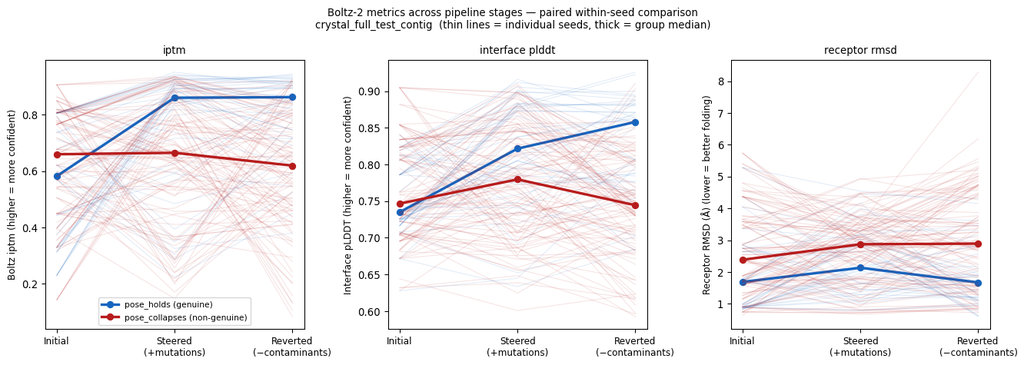

```python
fig, axes = plt.subplots(1, 3, figsize=(14, 5))
stages = ["Initial", "Steered\n(+mutations)", "Reverted\n(−contaminants)"]
x = [0, 1, 2]

COLOURS = {"pose_holds": "#1565C0", "pose_collapses": "#B71C1C"}
LABELS  = {"pose_holds": "pose_holds (genuine)", "pose_collapses": "pose_collapses (non-genuine)"}

for ax, (metric, (_, _, ylabel)) in zip(axes, METRICS.items()):
    ic = f"init_{metric}"; sc = f"steered_{metric}"; rc = f"reverted_{metric}"

    for verdict, grp, col in [
        ("pose_holds",    ph, COLOURS["pose_holds"]),
        ("pose_collapses",pc, COLOURS["pose_collapses"]),
    ]:
        # Individual trajectories (thin, transparent)
        for _, row in grp.iterrows():
            ax.plot(x, [row[ic], row[sc], row[rc]],
                    color=col, alpha=0.12, linewidth=0.8)

        # Median trajectory (thick)
        medians = [grp[ic].median(), grp[sc].median(), grp[rc].median()]
        ax.plot(x, medians, color=col, linewidth=2.5,
                marker="o", markersize=6, label=LABELS[verdict])

    ax.set_xticks(x)
    ax.set_xticklabels(stages, fontsize=9)
    ax.set_ylabel(ylabel, fontsize=9)
    ax.set_title(metric.replace("_", " "), fontsize=10)
    if ax == axes[0]:
        ax.legend(fontsize=8)

fig.suptitle("Boltz-2 metrics across pipeline stages — paired within-seed comparison\n"
             "crystal_full_test_contig  (thin lines = individual seeds, thick = group median)",
             fontsize=10)
plt.tight_layout()
plt.savefig(OUT_DIR / "a2_trajectory_all_metrics.png", bbox_inches="tight")
plt.show()
```

### 4.2 Change at each transition

The two key transitions are:

- **Δ steer** = steered − initial (effect of adding steering mutations)
- **Δ revert** = reverted − steered (effect of removing contaminating mutations)

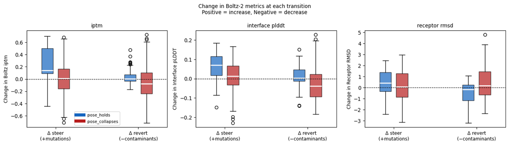

```python
fig, axes = plt.subplots(1, 3, figsize=(14, 4))

for ax, (metric, (_, _, ylabel)) in zip(axes, METRICS.items()):
    ic = f"init_{metric}"; sc = f"steered_{metric}"; rc = f"reverted_{metric}"

    data_steer  = [ph[sc] - ph[ic], pc[sc] - pc[ic]]
    data_revert = [ph[rc] - ph[sc], pc[rc] - pc[sc]]

    positions = [0.8, 1.2, 2.8, 3.2]
    colours   = [COLOURS["pose_holds"], COLOURS["pose_collapses"]] * 2
    data_all  = data_steer + data_revert

    bp = ax.boxplot(data_all, positions=positions, widths=0.28,
                    patch_artist=True, notch=False,
                    medianprops=dict(color="white", linewidth=2))
    for patch, col in zip(bp["boxes"], colours):
        patch.set_facecolor(col)
        patch.set_alpha(0.7)

    ax.axhline(0, color="black", linewidth=0.8, linestyle="--")
    ax.set_xticks([1, 3])
    ax.set_xticklabels(["Δ steer\n(+mutations)", "Δ revert\n(−contaminants)"], fontsize=9)
    ax.set_ylabel(f"Change in {ylabel.split('(')[0].strip()}", fontsize=9)
    ax.set_title(metric.replace("_", " "), fontsize=10)

legend_handles = [
    mlines.Line2D([], [], color=COLOURS["pose_holds"],    linewidth=6, label="pose_holds"),
    mlines.Line2D([], [], color=COLOURS["pose_collapses"],linewidth=6, label="pose_collapses"),
]
axes[0].legend(handles=legend_handles, fontsize=8)

fig.suptitle("Change in Boltz-2 metrics at each transition\n"
             "Positive = increase, Negative = decrease",
             fontsize=10)
plt.tight_layout()
plt.savefig(OUT_DIR / "a2_deltas_boxplot.png", bbox_inches="tight")
plt.show()
```

### 4.3 Summary table

```python
rows = []
for metric, (_, _, label) in METRICS.items():
    ic = f"init_{metric}"; sc = f"steered_{metric}"; rc = f"reverted_{metric}"
    for verdict, grp in [("pose_holds", ph), ("pose_collapses", pc)]:
        d_steer  = (grp[sc] - grp[ic]).median()
        d_revert = (grp[rc] - grp[sc]).median()
        rows.append({
            "Metric":          metric,
            "Verdict":         verdict,
            "Initial (median)":  round(grp[ic].median(), 3),
            "Steered (median)":  round(grp[sc].median(), 3),
            "Reverted (median)": round(grp[rc].median(), 3),
            "Δ steer (median)":  round(d_steer, 3),
            "Δ revert (median)": round(d_revert, 3),
        })

summary = pd.DataFrame(rows)

def colour_delta(val):
    if not isinstance(val, (int, float)) or np.isnan(val): return ""
    # For RMSD: negative delta is good (lower RMSD). For iptm/plddt: positive is good.
    return "background-color: #e8f5e9" if val > 0.01 else (
           "background-color: #ffebee" if val < -0.01 else "")

display(summary.style.hide(axis="index")
        .map(colour_delta, subset=["Δ steer (median)", "Δ revert (median)"])
        .set_properties(**{"text-align": "left"})
        .set_table_styles([{"selector": "th", "props": [("text-align", "left")]}]))
```

| Metric | Verdict | Initial (median) | Steered (median) | Reverted (median) | Δ steer (median) | Δ revert (median) |
| --- | --- | --- | --- | --- | --- | --- |
| iptm | pose_holds | 0.582000 | 0.860000 | 0.862000 | 0.138000 | 0.004000 |
| iptm | pose_collapses | 0.660000 | 0.665000 | 0.619000 | 0.008000 | -0.079000 |
| interface_plddt | pose_holds | 0.735000 | 0.822000 | 0.858000 | 0.070000 | 0.004000 |
| interface_plddt | pose_collapses | 0.747000 | 0.780000 | 0.744000 | 0.013000 | -0.038000 |
| receptor_rmsd | pose_holds | 1.689000 | 2.134000 | 1.672000 | 0.428000 | -0.164000 |
| receptor_rmsd | pose_collapses | 2.386000 | 2.872000 | 2.894000 | 0.066000 | 0.156000 |

*Note: for iptm and interface pLDDT, positive Δ = improvement. For receptor RMSD, negative Δ = improvement (lower RMSD = better folded receptor).*

### 5.1 Design

A **mixed two-way ANOVA** tests whether receptor RMSD differs systematically across:

- **Within-subjects factor: stage** (initial, steered, reverted) — each seed is measured at all three stages, so this is a repeated-measures factor.
- **Between-subjects factor: verdict** (pose_holds, pose_collapses) — each seed belongs to exactly one verdict group.
- **Interaction: stage × verdict** — tests whether the pattern of RMSD change across stages differs between verdict groups.

Each subject is one unique (design, seq, seed, steering_attempt) combination. The initial RMSD is the same for all seeds from the same design-sequence pair, which violates strict independence at that level. This is noted as a limitation but does not affect the steered → reverted paired comparisons.

```python
import pingouin as pg

# Reshape to long format: one row per (subject, stage)
long_rows = []
for _, row in paired.iterrows():
    for stage, col in [
        ("initial",  "init_receptor_rmsd"),
        ("steered",  "steered_receptor_rmsd"),
        ("reverted", "reverted_receptor_rmsd"),
    ]:
        long_rows.append({
            "subject":      row["subject"],
            "verdict":      row["verdict"],
            "stage":        stage,
            "receptor_rmsd": row[col],
        })

long_df = pd.DataFrame(long_rows).dropna(subset=["receptor_rmsd"])

# Enforce stage ordering for display
stage_order = ["initial", "steered", "reverted"]
long_df["stage"] = pd.Categorical(long_df["stage"], categories=stage_order, ordered=True)

print(f"Long-format dataset: {len(long_df)} rows  "
      f"({long_df['subject'].nunique()} subjects × 3 stages)")
print(f"  pose_holds:    {(long_df.verdict=='pose_holds').sum() // 3} subjects")
print(f"  pose_collapses:{(long_df.verdict=='pose_collapses').sum() // 3} subjects")
```

```
Long-format dataset: 429 rows  (143 subjects × 3 stages)
  pose_holds:    41 subjects
  pose_collapses:102 subjects
```

### 5.2 Mixed ANOVA results

```python
aov = pg.mixed_anova(
    dv="receptor_rmsd",
    within="stage",
    between="verdict",
    subject="subject",
    data=long_df,
)

display(aov[["Source","DF1","DF2","F","p_unc","np2","eps"]]
        .rename(columns={"DF1":"df1","DF2":"df2",
                         "p_unc":"p (uncorrected)",
                         "np2":"η²p (partial)",
                         "eps":"ε (sphericity)"})
        .style.hide(axis="index")
        .format({"F": "{:.3f}", "p (uncorrected)": "{:.4f}",
                 "η²p (partial)": "{:.4f}",
                 "ε (sphericity)": lambda x: f"{x:.3f}" if pd.notna(x) else "—"})
        .map(lambda v: "background-color: #e8f5e9"
             if isinstance(v, float) and v < 0.05 else "",
             subset=["p (uncorrected)"])
        .set_properties(**{"text-align": "left"}))
```

| Source | df1 | df2 | F | p (uncorrected) | η²p (partial) | ε (sphericity) |
| --- | --- | --- | --- | --- | --- | --- |
| verdict | 1 | 141 | 14.162 | 0.0002 | 0.0913 | — |
| stage | 2 | 282 | 3.489 | 0.0318 | 0.0241 | 0.983 |
| Interaction | 2 | 282 | 5.867 | 0.0032 | 0.0399 | — |

### 5.3 Post-hoc pairwise comparisons — receptor RMSD

```python
posthoc = pg.pairwise_tests(
    dv="receptor_rmsd",
    within="stage",
    between="verdict",
    subject="subject",
    data=long_df,
    padjust="bonf",
)

# Select informative columns
cols = ["Contrast","stage","A","B","T","dof","p_unc","p_corr","hedges"]
display(posthoc[cols]
        .rename(columns={"p_unc":"p (uncorrected)","p_corr":"p (Bonferroni)","hedges":"Hedges g"})
        .round({"T": 3, "p (uncorrected)": 4, "p (Bonferroni)": 4, "Hedges g": 3})
        .style.hide(axis="index")
        .map(lambda v: "background-color: #e8f5e9" if isinstance(v, float) and v < 0.05 else "",
             subset=["p (Bonferroni)"])
        .set_properties(**{"text-align": "left"}))
```

| Contrast | stage | A | B | T | dof | p (uncorrected) | p (Bonferroni) | Hedges g |
| --- | --- | --- | --- | --- | --- | --- | --- | --- |
| stage | - | initial | steered | -1.614000 | 142.000000 | 0.108800 | 0.326300 | -0.147000 |
| stage | - | initial | reverted | -2.747000 | 142.000000 | 0.006800 | 0.020400 | -0.192000 |
| stage | - | steered | reverted | -0.863000 | 142.000000 | 0.389500 | 1.000000 | -0.075000 |
| verdict | - | pose_collapses | pose_holds | 4.288000 | 100.213212 | 0.000000 | nan | 0.692000 |
| stage * verdict | initial | pose_collapses | pose_holds | 2.906000 | 82.741960 | 0.004700 | 0.014100 | 0.508000 |
| stage * verdict | steered | pose_collapses | pose_holds | 1.809000 | 76.514215 | 0.074400 | 0.223300 | 0.327000 |
| stage * verdict | reverted | pose_collapses | pose_holds | 5.394000 | 119.180978 | 0.000000 | 0.000000 | 0.811000 |

### 5.4 Visualising the group means with confidence intervals

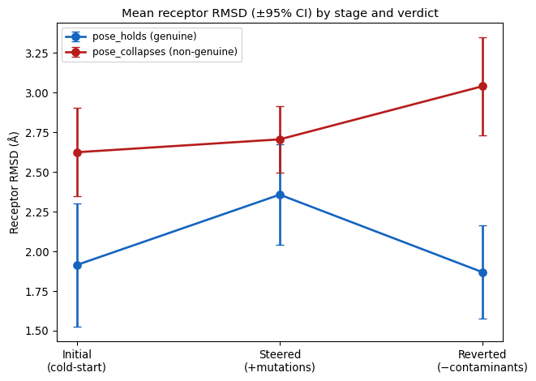

```python
fig, ax = plt.subplots(figsize=(7, 5))

for verdict, col, label in [
    ("pose_holds",    "#1565C0", "pose_holds (genuine)"),
    ("pose_collapses","#B71C1C", "pose_collapses (non-genuine)"),
]:
    grp = long_df[long_df["verdict"] == verdict]
    means = grp.groupby("stage")["receptor_rmsd"].mean().reindex(stage_order)
    sems  = grp.groupby("stage")["receptor_rmsd"].sem().reindex(stage_order)
    x = range(len(stage_order))
    ax.errorbar(x, means, yerr=sems * 1.96, fmt="o-",
                color=col, linewidth=2, markersize=7,
                capsize=4, label=label)

ax.set_xticks(range(len(stage_order)))
ax.set_xticklabels(["Initial\n(cold-start)", "Steered\n(+mutations)",
                    "Reverted\n(−contaminants)"], fontsize=10)
ax.set_ylabel("Receptor RMSD (Å)", fontsize=10)
ax.set_title("Mean receptor RMSD (±95% CI) by stage and verdict", fontsize=11)
ax.legend(fontsize=9)
plt.tight_layout()
plt.savefig(OUT_DIR / "a2_rmsd_means_ci.png", bbox_inches="tight")
plt.show()
```

## 6 Interpretation

> *Questions to address:*

> **Trajectory plots and delta boxplots:**
> - *For pose_holds designs: does adding steering mutations increase or* *decrease iptm and interface pLDDT? Is the direction consistent across* *individual seeds (do most lines move upward), or is it a median effect* *driven by outliers?*
> - *After reversion in pose_holds designs: does iptm recover, stay the* *same, or drop? What does this tell you about whether the genuine* *contact mutations are the source of Boltz’s confidence, or whether the* *underlying design was already good enough without them?*
> - *Receptor RMSD may show a different pattern from iptm and pLDDT.* *What does it mean if RMSD increases with steering mutations but recovers* *after reversion — or does not recover?*
> - *The initial iptm for pose_holds designs is lower than for* *pose_collapses. Why might designs that will form genuine interface* *contacts start at lower cold-start Boltz confidence?*

> **Implications:**
> - *The representative Boltz metrics in Analysis 1 (cross_sequence_summary)* *are post-steering/post-reversion. In light of this analysis, what* *exactly are those features capturing — the quality of the original* *design, or the quality of the mutations that steering added?*